# Importing and Processing CSV Files

## Next Steps

I think you should evaluate every month and see what happens. You might also consider looking at the TMIN as well. Could be important!

## Lets try Dec

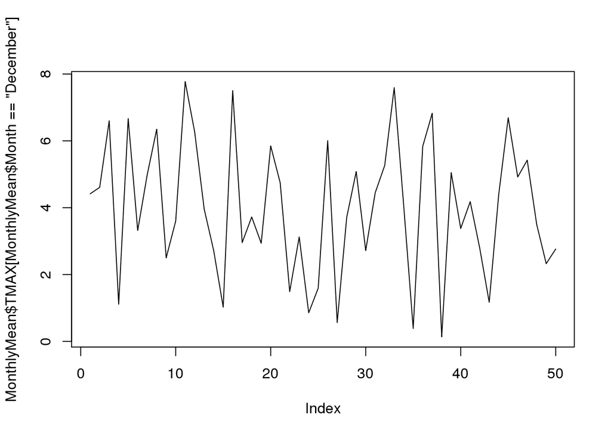

```r
plot(MonthlyMean$TMAX[MonthlyMean$Month=="December"], ty='l')
```

```r
plot(TMAX~YEAR, data=MonthlyMean[MonthlyMean$Month=="December",], ty='l')
Dec.lm <- lm(TMAX~YEAR, data=MonthlyMean[MonthlyMean$Month=="December",])
summary(Dec.lm)
```

```
##
## Call:
## lm(formula = TMAX ~ YEAR, data = MonthlyMean[MonthlyMean$Month ==
##     "December", ])
##
## Residuals:
##     Min      1Q  Median      3Q     Max
## -3.6681 -1.1900 -0.1483  1.6416  3.7309
##
## Coefficients:
##             Estimate Std. Error t value Pr(>|t|)
## (Intercept) 26.95757   25.72931   1.048    0.300
## YEAR        -0.01183    0.01325  -0.892    0.377
##
## Residual standard error: 2.034 on 48 degrees of freedom
## Multiple R-squared:  0.01632,    Adjusted R-squared:  -0.004172
## F-statistic: 0.7964 on 1 and 48 DF,  p-value: 0.3766
```

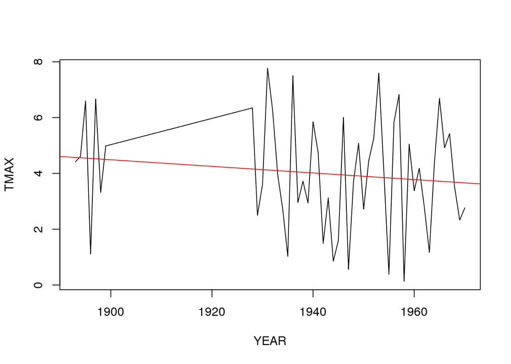

```r
abline(coef(Dec.lm), col="red")
```

## TMIN

1. We create a monthly mean for each month.

```r
MonthlyMeanTMIN = aggregate(TMIN ~ Month + Year, poughkeepsie, mean)

MonthlyMeanTMIN$YEAR = as.numeric(MonthlyMeanTMIN$Year)
head(MonthlyMeanTMIN)
```

```
##      Month Year       TMIN YEAR
## 1    April 1893   1.186667 1893
## 2   August 1893  13.700000 1893
## 3 December 1893  -7.856667 1893
## 4 February 1893 -10.750000 1893
## 5  January 1893 -15.593548 1893
## 6     July 1893  12.383871 1893
```

2. Now we plot the mins, and again, find tons of scatter.

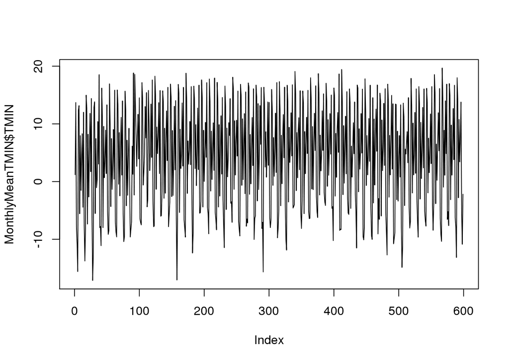

```r
plot(MonthlyMeanTMIN$TMIN, ty='l')
```

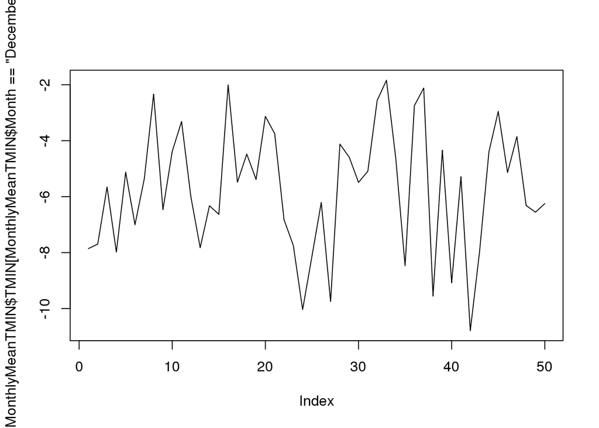

```r
plot(MonthlyMeanTMIN$TMIN[MonthlyMeanTMIN$Month=="December"], ty='l')
```

```r
plot(TMIN~YEAR, data=MonthlyMeanTMIN[MonthlyMeanTMIN$Month=="December",], ty='l')
Dec.lm <- lm(TMIN~YEAR, data=MonthlyMeanTMIN[MonthlyMeanTMIN$Month=="December",])
summary(Dec.lm)
```

```
##
## Call:
## lm(formula = TMIN ~ YEAR, data = MonthlyMeanTMIN[MonthlyMeanTMIN$Month ==
##     "December", ])
##
## Residuals:
##     Min      1Q  Median      3Q     Max
## -5.2446 -1.3984  0.2842  1.4262  3.7928
##
## Coefficients:
##               Estimate Std. Error t value Pr(>|t|)
## (Intercept) -24.261197  28.538284  -0.850    0.399
## YEAR          0.009539   0.014698   0.649    0.519
##
## Residual standard error: 2.256 on 48 degrees of freedom
## Multiple R-squared:  0.008699,   Adjusted R-squared:  -0.01195
## F-statistic: 0.4212 on 1 and 48 DF,  p-value: 0.5194
```

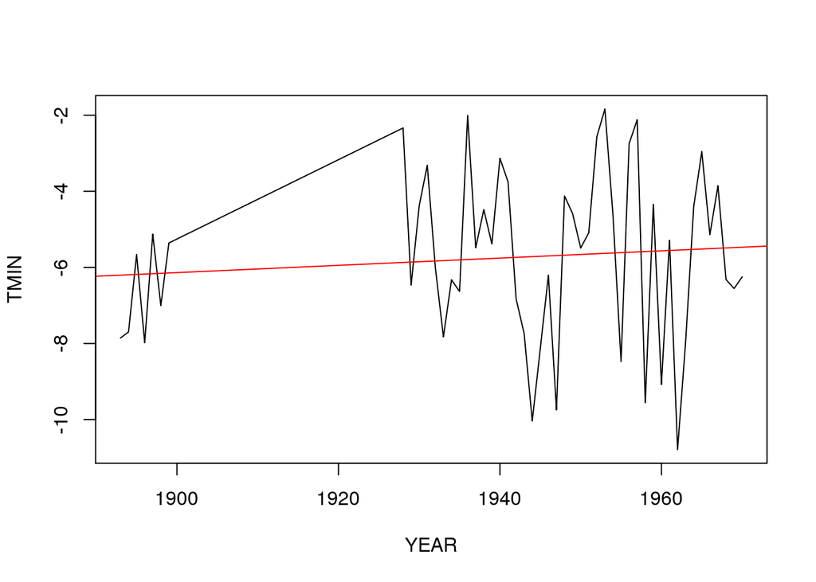

```r
abline(coef(Dec.lm), col="red")
```

3. In this case, we get a slope, 0.009539 degress/year and a probability of 0.5194195 and an r-sqaured of 0.009. Cool! As we might expect, the a small amount of the variance is explained by the “Month”. Many things predict temerpature, that year is one, is quite problematic.
4. What we have not determined is the cause. So, be careful when you describe the results, cause and effect cannot be analyzed using this method.